# Confounded Treatment and Blocking Structure

Statistics

Experimental Design

Published

February 10, 2021

Encounted a problem that the treatment is confounded with the blocking structure. In this situation, it is not possible to assess the interaction of the treatment and genotypes.

#### Example

Here is an example of the trial:

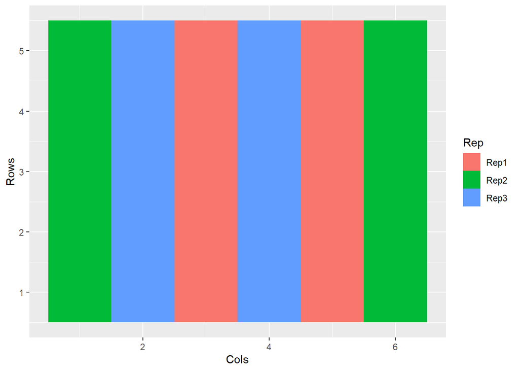

```r
set.seed(1234)
Rep <- rep(as.vector(replicate(2,sample(c("Rep1","Rep2","Rep3"),3))),each=5)
Gens <- paste0("Gen",1:5)
Geno <- as.vector(replicate(6, sample(Gens,5)))
TOS <- rep(c("TOS1","TOS2"),each=15)
Rows <- rep(1:5,6)
Cols <- rep(1:6,each=5)
dat <- data.frame(Rows,Cols,Rep,Geno,TOS)
ggplot(dat) + geom_tile(aes(Cols,Rows,fill=Rep))
```

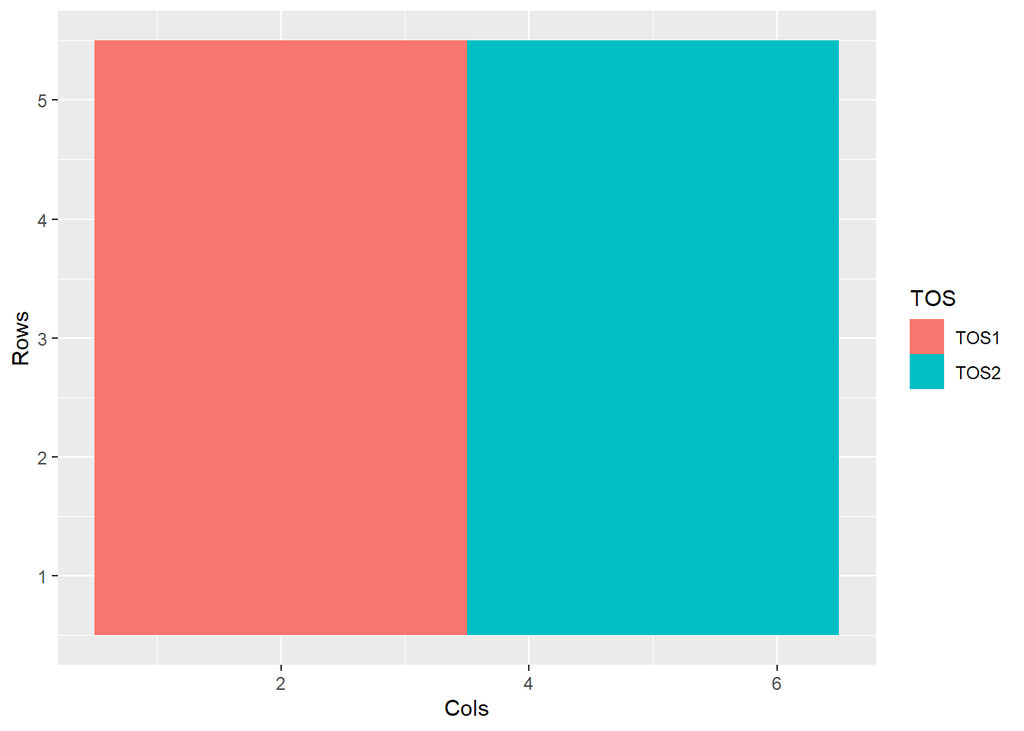

```r
ggplot(dat) + geom_tile(aes(Cols,Rows,fill=TOS))
```

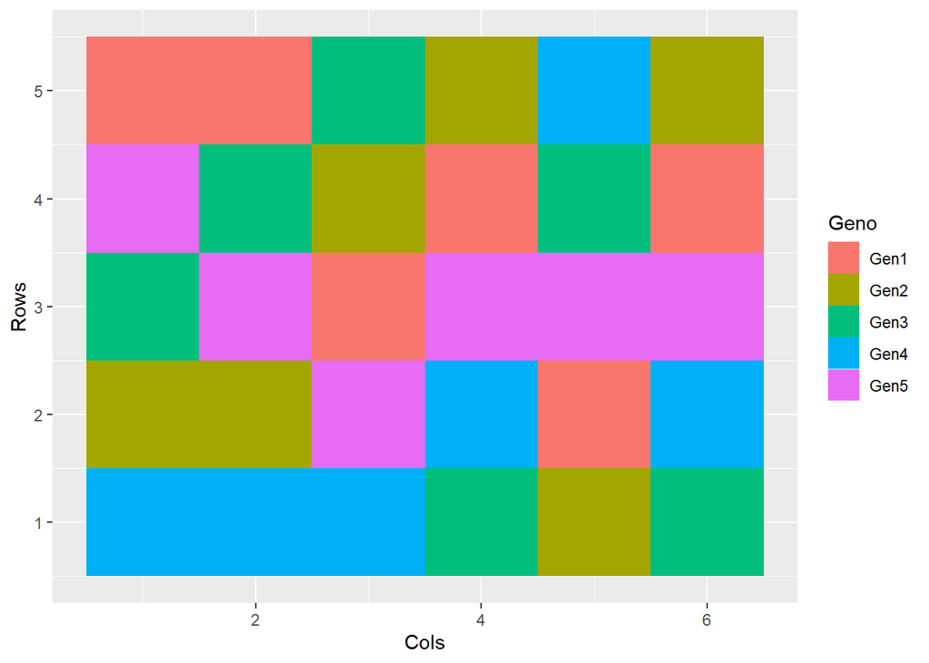

```r
ggplot(dat) + geom_tile(aes(Cols,Rows,fill=Geno))
```

```r
dat$y <- 3+rnorm(length(Rep))
names(dat)
```

```
## [1] "Rows" "Cols" "Rep"  "Geno" "TOS"  "y"
```

```r
nms <- c("Rows","Cols","Rep","Geno","TOS")
dat[nms] <- lapply(dat[nms], factor)
```

The researchers would like to assess the effects of different Time of Sowing, Genotypes and their interactions on a set of traits.

#### Model 1

With the trial, the interaction is not possibly being assessed because the treatment is confounded with the blocking structure.

```r
mod1 <- asreml(y ~ TOS*Geno,
               random = ~ TOS:Rep,
               data = dat)
```

```
## Online License checked out Thu Mar  4 16:57:37 2021
## Model fitted using the gamma parameterization.
## ASReml 4.1.0 Thu Mar  4 16:57:37 2021
##           LogLik        Sigma2     DF     wall    cpu
##  1      -12.0709      0.654877     20 16:57:37    0.0
##  2      -12.0484      0.644739     20 16:57:37    0.0
##  3      -12.0259      0.624656     20 16:57:37    0.0
##  4      -12.0256      0.622321     20 16:57:37    0.0
```

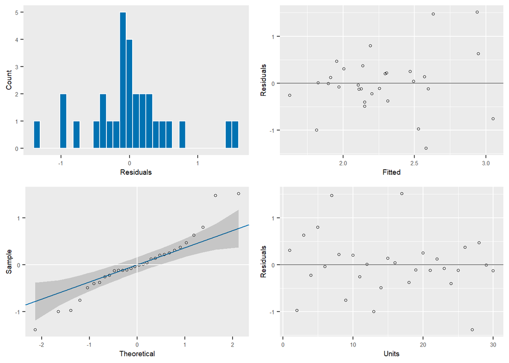

```r
plot(mod1)
```

```r
wald(mod1,denDF = "default",ssType = "conditional")
```

```
## Model fitted using the gamma parameterization.
## ASReml 4.1.0 Thu Mar  4 16:57:37 2021
##           LogLik        Sigma2     DF     wall    cpu
##  1      -12.0256      0.622286     20 16:57:37    0.0
##  2      -12.0256      0.622286     20 16:57:37    0.0
##  3      -12.0256      0.622286     20 16:57:37    0.0
```

```
## $Wald
##
## Wald tests for fixed effects.
## Response: y
##
##             Df denDF   F.inc   F.con Margin      Pr
## (Intercept)  1     4 131.600 131.600        0.00033
## TOS          1     4   0.003   0.003      A 0.95740
## Geno         4    16   0.394   0.394      A 0.80986
## TOS:Geno     4    16   0.619   0.619      B 0.65513
##
## $stratumVariances
##         df  Variance TOS:Rep units!R
## TOS:Rep  4 1.1778601       5       1
## units!R 16 0.6222861       0       1
```

#### Model 2

The two TOS blocks were treated as two different environments. As such, a MET analysis techniques were used assuming heterogeneous variance for both TOS.

```r
mod2 <- asreml(y ~ TOS + Geno,
               random = ~ at(TOS):Rep,
               data = dat)
```

```
## Model fitted using the gamma parameterization.
## ASReml 4.1.0 Thu Mar  4 16:57:37 2021
##           LogLik        Sigma2     DF     wall    cpu
##  1      -12.3657      0.609972     24 16:57:37    0.0
##  2      -12.3039      0.599510     24 16:57:37    0.0
##  3      -12.2332      0.579837     24 16:57:37    0.0
##  4      -12.2288      0.575302     24 16:57:37    0.0
```

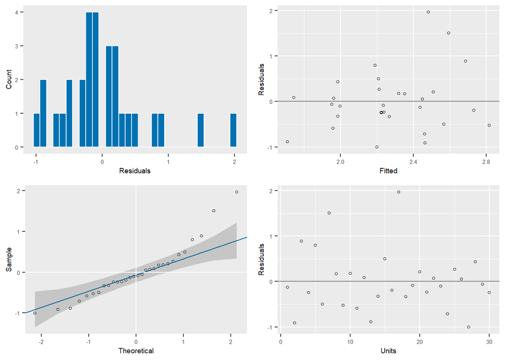

```r
plot(mod2)
```

```r
wald(mod2,denDF = "default",ssType = "conditional")
```

```
## Model fitted using the gamma parameterization.
## ASReml 4.1.0 Thu Mar  4 16:57:38 2021
##           LogLik        Sigma2     DF     wall    cpu
##  1      -12.2287      0.574921     24 16:57:38    0.0
##  2      -12.2287      0.574920     24 16:57:38    0.0
##  3      -12.2287      0.574918     24 16:57:38    0.0
```

```
## $Wald
##
## Wald tests for fixed effects.
## Response: y
##
##             Df denDF   F.inc   F.con Margin      Pr
## (Intercept)  1   3.8 138.100 138.100        0.00039
## TOS          1   3.8   0.003   0.003      A 0.95753
## Geno         4  20.0   0.427   0.427      A 0.78766
##
## $stratumVariances
##                   df  Variance at(TOS, TOS1):Rep at(TOS, TOS2):Rep units!R
## at(TOS, TOS1):Rep  2 1.4385847                 5     -2.297635e-17       1
## at(TOS, TOS2):Rep  2 0.9171355                 0      5.000000e+00       1
## units!R           20 0.5749179                 0      0.000000e+00       1
```

Hans-Peter has a paper discussing this issue and an example shows that there is complete confounding of area and treatment effects. So the `model 1` in our case is not valid.

#### References

- Hans-Peter Piepho, Mian Faisal Nazir, M. Kausar Nawaz Shah (2016). Design and analysis of a trial to select for stress tolerance. COMMUNICATIONS IN BIOMETRY AND CROP SCIENCE. VOL. 11, NO. 1, 2016, PP. 1–9